# Homework 3 - INFSCI 2160: Data Mining

## 17 Oct 2017

### Meng Li (mel165@pitt.edu) | Junchao Mei (jum68@pitt.edu) | Hyunseok Choi (hyc23@pitt.edu)

#### The objective is to predict the binary (TARGET_Adjusted) target variables.

## Data Preprocessing

```r
# Load data
data.file = 'audit.csv'
ad = read.csv(data.file , header = TRUE , sep = ',')
head(ad)
```

| ID | Age | Employment | Education | Marital | Occupation | Income | Gender | Deductions | Hours | RISK_Adjustment | TARGET_Adjusted |
| --- | --- | --- | --- | --- | --- | --- | --- | --- | --- | --- | --- |
| 1004641 | 38 | Private | College | Unmarried | Service | 81838.00 | Female | 0 | 72 | 0 | 0 |
| 1010229 | 35 | Private | Associate | Absent | Transport | 72099.00 | Male | 0 | 30 | 0 | 0 |
| 1024587 | 32 | Private | HSgrad | Divorced | Clerical | 154676.74 | Male | 0 | 40 | 0 | 0 |
| 1038288 | 45 | Private | Bachelor | Married | Repair | 27743.82 | Male | 0 | 55 | 7298 | 1 |
| 1044221 | 60 | Private | College | Married | Executive | 7568.23 | Male | 0 | 40 | 15024 | 1 |
| 1047095 | 74 | Private | HSgrad | Married | Service | 33144.40 | Male | 0 | 30 | 0 | 0 |

```r
# delete unused variables, ID and RISK_Adjustment.
drops = c('ID','RISK_Adjustment')
ad = ad[,!(names(ad) %in% drops)]
# set classifier variable (TARGET_Adjusted) as column one,
# and rename it as y
ad = cbind(y=ad$TARGET_Adjusted,ad)
ad$TARGET_Adjusted = NULL
ad$y <- as.factor(ad$y)
head(ad)
```

| y | Age | Employment | Education | Marital | Occupation | Income | Gender | Deductions | Hours |
| --- | --- | --- | --- | --- | --- | --- | --- | --- | --- |
| 0 | 38 | Private | College | Unmarried | Service | 81838.00 | Female | 0 | 72 |
| 0 | 35 | Private | Associate | Absent | Transport | 72099.00 | Male | 0 | 30 |
| 0 | 32 | Private | HSgrad | Divorced | Clerical | 154676.74 | Male | 0 | 40 |
| 1 | 45 | Private | Bachelor | Married | Repair | 27743.82 | Male | 0 | 55 |
| 1 | 60 | Private | College | Married | Executive | 7568.23 | Male | 0 | 40 |
| 0 | 74 | Private | HSgrad | Married | Service | 33144.40 | Male | 0 | 30 |

```r
# Scaling with range (0 ~ 1)
scaling <- function(x){
   return((x-min(x))/(max(x)-min(x)))
}

ad$Age <- scaling(ad$Age)
ad$Income <- scaling(ad$Income)
ad$Deductions <- scaling(ad$Deductions)
ad$Hours <- scaling(ad$Hours)
```

```r
# Handling NA Values

any(is.na(ad))
# delete rows with the value of "NA"
ad=na.omit(ad)
# check missing value again
any(is.na(ad))
print(dim(ad)) # Now we have 1899 observations (reduced from original 2000 observations)
```

TRUE

FALSE

```
[1] 1899   10
```

```r
## Singular Values Processing
# check all the values of occupation and employment
levels(ad$Occupation)
levels(ad$Employment)
# delete the unmeaningful observations:
ad <- ad[(ad$Employment != 'Unemployed'),]; dim(ad)
ad <- ad[(ad$Employment != 'Volunteer'),]; dim(ad)
ad <- ad[(ad$Occupation != 'Military'),]; dim(ad)
# Drop unused levels
ad$Occupation <- droplevels(ad$Occupation)
levels(ad$Occupation)
ad$Employment <- droplevels(ad$Employment)
levels(ad$Employment)
```

1. 'Cleaner'

2. 'Clerical'

3. 'Executive'

4. 'Farming'

5. 'Home'

6. 'Machinist'

7. 'Military'

8. 'Professional'

9. 'Protective'

10. 'Repair'

11. 'Sales'

12. 'Service'

13. 'Support'

14. 'Transport'

1. 'Consultant'

2. 'PSFederal'

3. 'PSLocal'

4. 'PSState'

5. 'Private'

6. 'SelfEmp'

7. 'Unemployed'

8. 'Volunteer'

1. 1899

2. 10

1. 1898

2. 10

1. 1897

2. 10

1. 'Cleaner'

2. 'Clerical'

3. 'Executive'

4. 'Farming'

5. 'Home'

6. 'Machinist'

7. 'Professional'

8. 'Protective'

9. 'Repair'

10. 'Sales'

11. 'Service'

12. 'Support'

13. 'Transport'

1. 'Consultant'

2. 'PSFederal'

3. 'PSLocal'

4. 'PSState'

5. 'Private'

6. 'SelfEmp'

```r
summary(ad)
```

```
 y             Age              Employment        Education
 0:1450   Min.   :0.0000   Consultant: 148   HSgrad    :633
 1: 447   1st Qu.:0.1507   PSFederal :  68   College   :417
          Median :0.2740   PSLocal   : 119   Bachelor  :332
          Mean   :0.2918   PSState   :  72   Master    : 98
          3rd Qu.:0.4110   Private   :1411   Vocational: 81
          Max.   :0.9041   SelfEmp   :  79   Associate : 66
                                             (Other)   :270
                  Marital           Occupation      Income           Gender
 Absent               :632   Executive   :289   Min.   :0.00000   Female: 592
 Divorced             :256   Professional:247   1st Qu.:0.06944   Male  :1305
 Married              :877   Clerical    :232   Median :0.12259
 Married-spouse-absent: 21   Repair      :225   Mean   :0.17435
 Unmarried            : 64   Service     :210   3rd Qu.:0.23472
 Widowed              : 47   Sales       :206   Max.   :1.00000
                             (Other)     :488
   Deductions          Hours
 Min.   :0.00000   Min.   :0.0000
 1st Qu.:0.00000   1st Qu.:0.3980
 Median :0.00000   Median :0.3980
 Mean   :0.02367   Mean   :0.4037
 3rd Qu.:0.00000   3rd Qu.:0.4490
 Max.   :0.97245   Max.   :1.0000
```

## Load Packages

```r
library(plyr)    # for recoding data
library(dummies) # for trasforming categorical features into dummy variables
library(ROCR)    # for plotting roc
library(e1071)   # for NB and SVM
library(rpart)   # for decision tree
library(ada)     # for adaboost
library(MASS)    # for example dataset
library(class)   # for knn
```

## Build Classification Model

```r
set.seed(12345) # set the seed so you can get exactly the same results whenever you run the code
```

```r
# Global variables to store performance measures and ROC curve data
performances = c("Model", "Accuracy", "Precision", "Recall", "F-score", "AUC")
roc_data = c("ROC")
```

```r
do.classification <- function(train.set, test.set, cl.name, verbose=F)
{
  ## note: to plot ROC later, we want the raw probabilities,
  ## not binary decisions
  switch(cl.name,
         # K Nearest Neighbors
         knn1 = {
           prob = knn(train.set[,-1], test.set[,-1], cl=train.set[,1], k = 1, prob=T)
           prob = attr(prob,"prob")
           #print(cbind(prob,as.character(test.set$y)))
           prob
         },
         knn3 = {
           prob = knn(train.set[,-1], test.set[,-1], cl=train.set[,1], k = 3, prob=T)
           prob = attr(prob,"prob")
           #print(cbind(prob,as.character(test.set$y)))
           prob
         },
         knn5 = {
           prob = knn(train.set[,-1], test.set[,-1], cl=train.set[,1], k = 5, prob=T)
           prob = attr(prob,"prob")
           #print(cbind(prob,as.character(test.set$y)))
           prob
         },

         # Logistic Regression
         lr = {
           model = glm(y~., family=binomial, data=train.set)
           if (verbose) {
             print(summary(model))
           }
           prob = predict(model, newdata=test.set, type="response")
           #print(cbind(prob,as.character(test.set$y)))
           prob
         },

         # Naive Bayes
         nb = {
           model = naiveBayes(y~., data=train.set)
           prob = predict(model, newdata=test.set, type="raw")
           #print(cbind(prob,as.character(test.set$y)))
           prob = prob[,2]/rowSums(prob) # renormalize the prob.
           prob
         },

         # Decision Tree
         dtree_not_pruned = {
           model = rpart(y~., data=train.set)
           if (verbose) {
             print(summary(model)) # detailed summary of splits
             printcp(model) # print the cross-validation results
             plotcp(model) # visualize the cross-validation results
             ## plot the tree
             plot(model, uniform=TRUE, main="Classification Tree")
             text(model, use.n=TRUE, all=TRUE, cex=.8)
           }
           prob = predict(model, newdata=test.set)
           #print(cbind(prob,as.character(test.set$y)))
           prob = prob[,2]/rowSums(prob) # renormalize the prob.
           prob
         },
         dtree_pruned = {
           model = rpart(y~., data=train.set)
           if (verbose) {
             print(summary(model)) # detailed summary of splits
             printcp(model) # print the cross-validation results
             plotcp(model) # visualize the cross-validation results
             ## plot the tree
             plot(model, uniform=TRUE, main="Classification Tree")
             text(model, use.n=TRUE, all=TRUE, cex=.8)
           }
           # prune the classification tree
           pfit<- prune(model,
                    cp=model$cptable[which.min(model$cptable[,"xerror"]),"CP"]) # choose the CP with the minimum xerror automatically
           prob = predict(pfit, newdata=test.set)
           ## plot the pruned tree
           plot(pfit, uniform=TRUE,main="Pruned Classification Tree")
           text(pfit, use.n=TRUE, all=TRUE, cex=.8)

           #print(cbind(prob,as.character(test.set$y)))
           prob = prob[,2]/rowSums(prob) # renormalize the prob.
           prob
         },

         # SVM
         svm_radial_not_tuned={
           model = svm(y~., data=train.set, probability=T)
           prob = predict(model, newdata=test.set, probability=T)
           prob = attr(prob,"probabilities")
           #print(cbind(prob,as.character(test.set$y)))
           #print(dim(prob))
           prob = prob[,which(colnames(prob)==1)]/rowSums(prob)
           prob
         },
         svm_radial_tuned = {
           model = svm(y~., data=train.set, probability=T)
           if (1) { # fine-tune the model with different kernel and parameters
             ## evaluate the range of gamma parameter between 0.000001 and 0.1
             ## and cost parameter from 0.1 until 10
             tuned <- tune.svm(y~., data = train.set,
                               kernel="radial",
                               gamma = 10^(-6:-1), cost = 10^(-1:1))
             #print(summary(tuned))
             gamma = tuned[['best.parameters']]$gamma
             cost = tuned[['best.parameters']]$cost
             model = svm(y~., data = train.set, probability=T,
                         kernel="radial", gamma=gamma, cost=cost)
           }
           prob = predict(model, newdata=test.set, probability=T)
           prob = attr(prob,"probabilities")
           #print(cbind(prob,as.character(test.set$y)))
           #print(dim(prob))
           prob = prob[,which(colnames(prob)==1)]/rowSums(prob)
           prob
         },
         svm_linear_not_tuned = {
           model = svm(y~., data=train.set, probability=T)
           prob = predict(model, newdata=test.set, probability=T)
           prob = attr(prob,"probabilities")
           #print(cbind(prob,as.character(test.set$y)))
           #print(dim(prob))
           prob = prob[,which(colnames(prob)==1)]/rowSums(prob)
           prob
         },
         svm_linear_tuned = {
           model = svm(y~., data=train.set, probability=T)
           if (1) { # fine-tune the model with different kernel and parameters
             ## evaluate the range of gamma parameter between 0.000001 and 0.1
             ## and cost parameter from 0.1 until 10
             tuned <- tune.svm(y~., data = train.set,
                               kernel="linear",
                               gamma = 10^(-6:-1), cost = 10^(-1:1))
             #print(summary(tuned))
             gamma = tuned[['best.parameters']]$gamma
             cost = tuned[['best.parameters']]$cost
             model = svm(y~., data = train.set, probability=T,
                         kernel="radial", gamma=gamma, cost=cost)
           }
           prob = predict(model, newdata=test.set, probability=T)
           prob = attr(prob,"probabilities")
           #print(cbind(prob,as.character(test.set$y)))
           #print(dim(prob))
           prob = prob[,which(colnames(prob)==1)]/rowSums(prob)
           prob
         },
         svm_polynomial_not_tuned = {
           model = svm(y~., data=train.set, probability=T)
           prob = predict(model, newdata=test.set, probability=T)
           prob = attr(prob,"probabilities")
           #print(cbind(prob,as.character(test.set$y)))
           #print(dim(prob))
           prob = prob[,which(colnames(prob)==1)]/rowSums(prob)
           prob
         },
         svm_polynomial_tuned = {
           model = svm(y~., data=train.set, probability=T)
           if (1) { # fine-tune the model with different kernel and parameters
             ## evaluate the range of gamma parameter between 0.000001 and 0.1
             ## and cost parameter from 0.1 until 10
             tuned <- tune.svm(y~., data = train.set,
                               kernel="polynomial",
                               gamma = 10^(-6:-1), cost = 10^(-1:1))
             #print(summary(tuned))
             gamma = tuned[['best.parameters']]$gamma
             cost = tuned[['best.parameters']]$cost
             model = svm(y~., data = train.set, probability=T,
                         kernel="radial", gamma=gamma, cost=cost)
           }
           prob = predict(model, newdata=test.set, probability=T)
           prob = attr(prob,"probabilities")
           #print(cbind(prob,as.character(test.set$y)))
           #print(dim(prob))
           prob = prob[,which(colnames(prob)==1)]/rowSums(prob)
           prob
         },

         # Ada Boost
         ada = {
           model = ada(y~., data = train.set)
           prob = predict(model, newdata=test.set, type='probs')
           #print(cbind(prob,as.character(test.set$y)))
           prob = prob[,2]/rowSums(prob)
           prob
         }
  )
}
```

```r
k.fold.cv <- function(dataset, cl.name, k.fold=10, prob.cutoff=0.5) {
  ## default: 10-fold CV, cut-off 0.5
  n.obs <- nrow(ad) # no. of observations
  s = sample(n.obs)
  errors = dim(k.fold)
  probs = NULL
  actuals = NULL
  for (k in 1:k.fold) {
    test.idx = which(s %% k.fold == (k-1) ) # use modular operator
    train.set = dataset[-test.idx,]
    test.set = dataset[test.idx,]
    cat(k.fold,'-fold CV run',k,cl.name,':',
        '#training:',nrow(train.set),
        '#testing',nrow(test.set),'\n')
    prob = do.classification(train.set, test.set, cl.name)
    predicted = as.numeric(prob > prob.cutoff)
    actual = test.set$y
    confusion.matrix = table(actual,factor(predicted,levels=c(0,1)))
    confusion.matrix
    error = (confusion.matrix[1,2]+confusion.matrix[2,1]) / nrow(test.set)
    errors[k] = error
    cat('\t\terror=',error,'\n')
    probs = c(probs,prob)
    actuals = c(actuals,actual)
    ## you may compute other measures and store them in arrays
  }
  avg.error = mean(errors)
  cat(k.fold,'-fold CV results:','avg error=',avg.error,'\n')

  ## plot ROC
  result = data.frame(probs,actuals)
  pred = prediction(result$probs,result$actuals)
  perf = performance(pred, "tpr","fpr")
  plot(perf)
  par(new=TRUE)


  ## get other measures by using 'performance'
  get.measure <- function(pred, measure.name='auc') {
    perf = performance(pred,measure.name)
    m <- unlist(slot(perf, "y.values"))
    m
  }
  err = mean(get.measure(pred, 'err'))
  precision = mean(get.measure(pred, 'prec'),na.rm=T)
  recall = mean(get.measure(pred, 'rec'),na.rm=T)
  fscore = mean(get.measure(pred, 'f'),na.rm=T)
  cat('error=',err,'precision=',precision,'recall=',recall,'f-score',fscore,'\n')
  auc = get.measure(pred, 'auc')
  cat('auc=',auc,'\n')

  ## store the performance measures to the global variable
  performances <<- rbind(performances, c(cl.name, 1-err, precision, recall, fscore, auc))
  roc_data <<- c(roc_data, perf)
}
```

```r
my.classifier <- function(dataset, cl.name='knn', do.cv=T) {
  n.obs <- nrow(ad) # no. of observations in dataset
  n.cols <- ncol(ad) # no. of predictors
  cat('my dataset:',
      n.obs,'observations',
      n.cols-1,'predictors','\n')
  print(dataset[1:3,])
  cat('label (y) distribution:')
  print(table(dataset$y))

#   pre.test(dataset, cl.name)
  if (do.cv) k.fold.cv(dataset, cl.name)
}
```

```
my dataset: 1897 observations 9 predictors
  y       Age Employment Education   Marital Occupation    Income Gender
1 0 0.2876712    Private   College Unmarried    Service 0.1689968 Female
2 0 0.2465753    Private Associate    Absent  Transport 0.1487347   Male
3 0 0.2054795    Private    HSgrad  Divorced   Clerical 0.3205390   Male
  Deductions     Hours
1          0 0.7244898
2          0 0.2959184
3          0 0.3979592
label (y) distribution:
   0    1
1450  447
10 -fold CV run 1 lr : #training: 1708 #testing 189
		error= 0.2275132
10 -fold CV run 2 lr : #training: 1707 #testing 190
		error= 0.1684211
10 -fold CV run 3 lr : #training: 1707 #testing 190
		error= 0.1894737
10 -fold CV run 4 lr : #training: 1707 #testing 190
		error= 0.1578947
10 -fold CV run 5 lr : #training: 1707 #testing 190
		error= 0.1315789
10 -fold CV run 6 lr : #training: 1707 #testing 190
		error= 0.1789474
10 -fold CV run 7 lr : #training: 1707 #testing 190
		error= 0.1157895
10 -fold CV run 8 lr : #training: 1707 #testing 190
		error= 0.1473684
10 -fold CV run 9 lr : #training: 1708 #testing 189
		error= 0.1851852
10 -fold CV run 10 lr : #training: 1708 #testing 189
```

```
		error= 0.1428571
10 -fold CV results: avg error= 0.1645029
error= 0.3660255 precision= 0.4760729 recall= 0.7842837 f-score 0.5090266
auc= 0.8721176
```

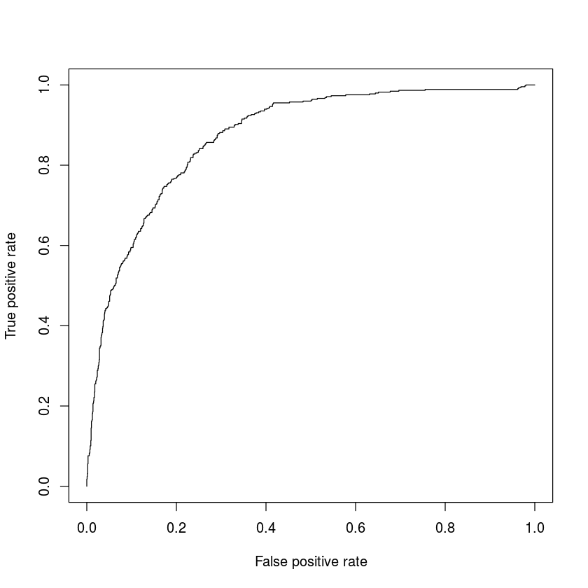

```r
my.classifier(ad, cl.name='lr',do.cv=T)
```

```
my dataset: 1897 observations 9 predictors
  y       Age Employment Education   Marital Occupation    Income Gender
1 0 0.2876712    Private   College Unmarried    Service 0.1689968 Female
2 0 0.2465753    Private Associate    Absent  Transport 0.1487347   Male
3 0 0.2054795    Private    HSgrad  Divorced   Clerical 0.3205390   Male
  Deductions     Hours
1          0 0.7244898
2          0 0.2959184
3          0 0.3979592
label (y) distribution:
   0    1
1450  447
10 -fold CV run 1 nb : #training: 1708 #testing 189
		error= 0.1534392
10 -fold CV run 2 nb : #training: 1707 #testing 190
		error= 0.2052632
10 -fold CV run 3 nb : #training: 1707 #testing 190
		error= 0.1947368
10 -fold CV run 4 nb : #training: 1707 #testing 190
		error= 0.1842105
10 -fold CV run 5 nb : #training: 1707 #testing 190
		error= 0.1789474
10 -fold CV run 6 nb : #training: 1707 #testing 190
		error= 0.1842105
10 -fold CV run 7 nb : #training: 1707 #testing 190
		error= 0.1894737
10 -fold CV run 8 nb : #training: 1707 #testing 190
		error= 0.1421053
10 -fold CV run 9 nb : #training: 1708 #testing 189
		error= 0.2169312
10 -fold CV run 10 nb : #training: 1708 #testing 189
		error= 0.1693122
10 -fold CV results: avg error= 0.181863
error= 0.3780771 precision= 0.439636 recall= 0.7765837 f-score 0.495539
auc= 0.8457016
```

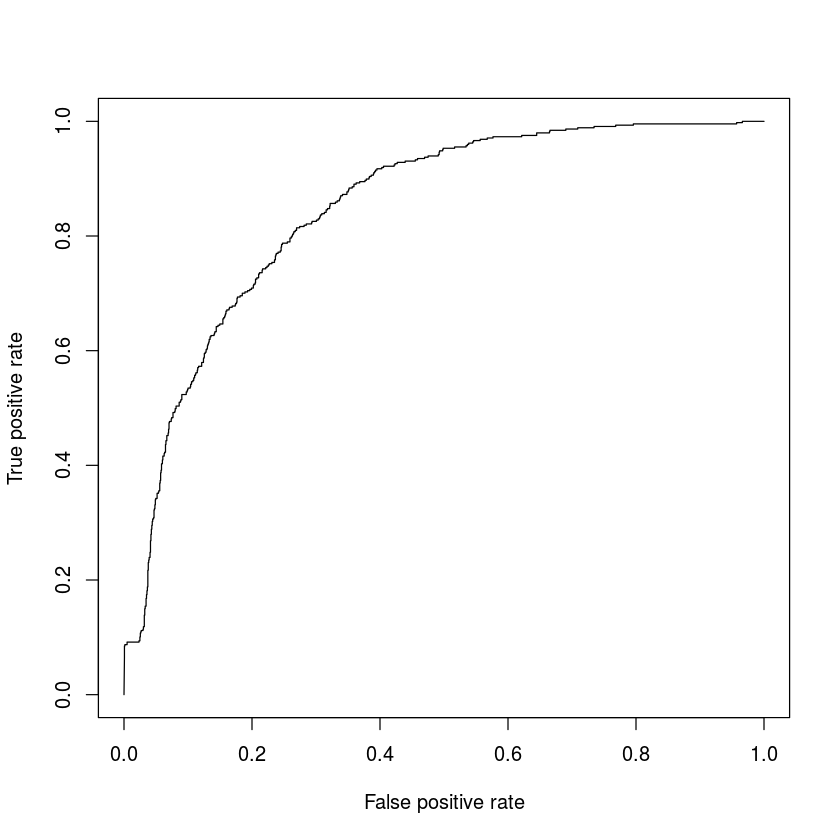

```r
my.classifier(ad, cl.name='nb',do.cv=T)
```

```
my dataset: 1897 observations 9 predictors
  y       Age Employment Education   Marital Occupation    Income Gender
1 0 0.2876712    Private   College Unmarried    Service 0.1689968 Female
2 0 0.2465753    Private Associate    Absent  Transport 0.1487347   Male
3 0 0.2054795    Private    HSgrad  Divorced   Clerical 0.3205390   Male
  Deductions     Hours
1          0 0.7244898
2          0 0.2959184
3          0 0.3979592
label (y) distribution:
   0    1
1450  447
10 -fold CV run 1 dtree_not_pruned : #training: 1708 #testing 189
		error= 0.1481481
10 -fold CV run 2 dtree_not_pruned : #training: 1707 #testing 190
		error= 0.1842105
10 -fold CV run 3 dtree_not_pruned : #training: 1707 #testing 190
		error= 0.1421053
10 -fold CV run 4 dtree_not_pruned : #training: 1707 #testing 190
		error= 0.1789474
10 -fold CV run 5 dtree_not_pruned : #training: 1707 #testing 190
		error= 0.1684211
10 -fold CV run 6 dtree_not_pruned : #training: 1707 #testing 190
		error= 0.1263158
10 -fold CV run 7 dtree_not_pruned : #training: 1707 #testing 190
		error= 0.2210526
10 -fold CV run 8 dtree_not_pruned : #training: 1707 #testing 190
		error= 0.1368421
10 -fold CV run 9 dtree_not_pruned : #training: 1708 #testing 189
		error= 0.1481481
10 -fold CV run 10 dtree_not_pruned : #training: 1708 #testing 189
		error= 0.1693122
10 -fold CV results: avg error= 0.1623503
error= 0.2533363 precision= 0.6002093 recall= 0.5661427 f-score 0.5034745
auc= 0.8203525
```

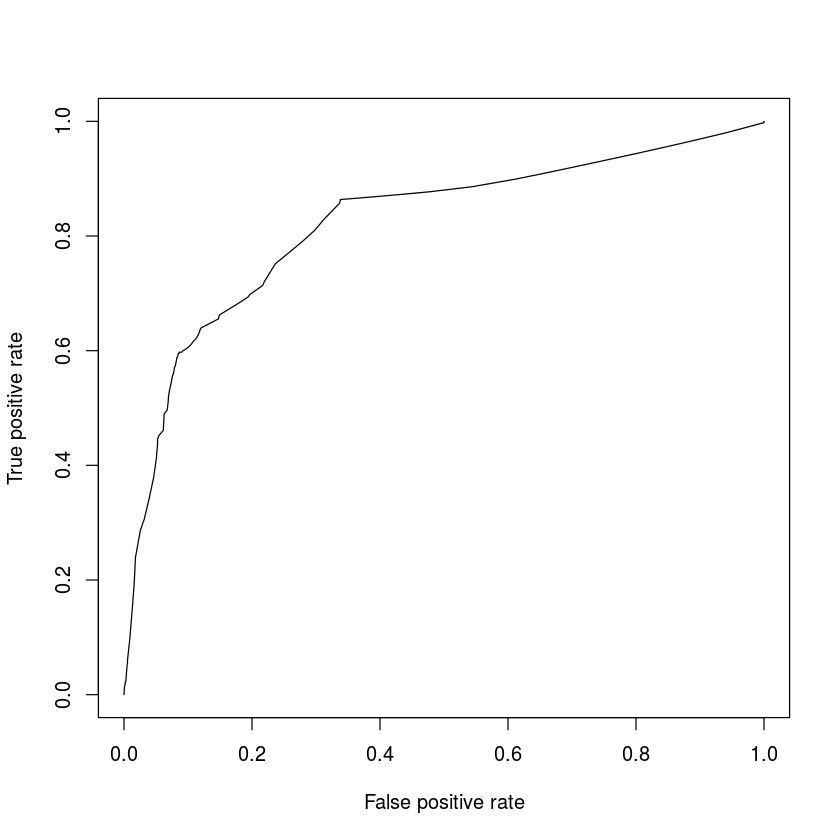

```r
my.classifier(ad, cl.name='dtree_not_pruned',do.cv=T)
```

```
my dataset: 1897 observations 9 predictors
  y       Age Employment Education   Marital Occupation    Income Gender
1 0 0.2876712    Private   College Unmarried    Service 0.1689968 Female
2 0 0.2465753    Private Associate    Absent  Transport 0.1487347   Male
3 0 0.2054795    Private    HSgrad  Divorced   Clerical 0.3205390   Male
  Deductions     Hours
1          0 0.7244898
2          0 0.2959184
3          0 0.3979592
label (y) distribution:
   0    1
1450  447
10 -fold CV run 1 dtree_pruned : #training: 1708 #testing 189
		error= 0.1481481
10 -fold CV run 2 dtree_pruned : #training: 1707 #testing 190
```

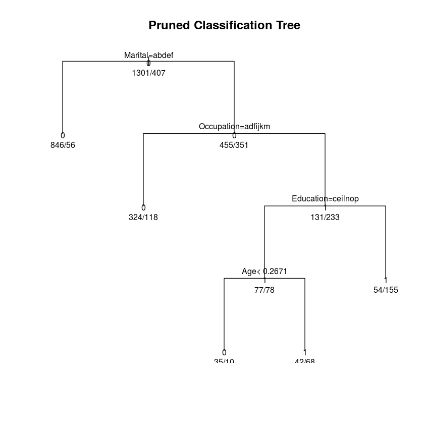

```
		error= 0.1631579
10 -fold CV run 3 dtree_pruned : #training: 1707 #testing 190
```

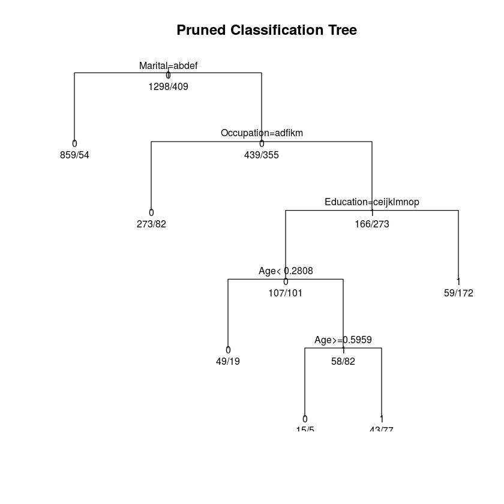

```
		error= 0.1263158
10 -fold CV run 4 dtree_pruned : #training: 1707 #testing 190
```

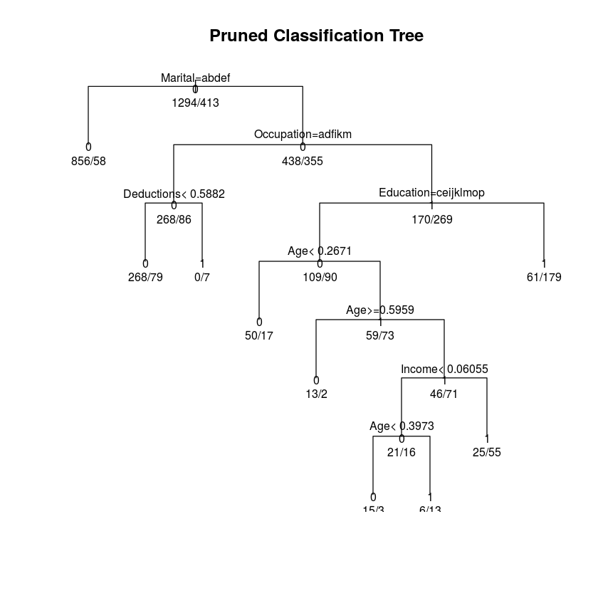

```
		error= 0.2105263
10 -fold CV run 5 dtree_pruned : #training: 1707 #testing 190
```

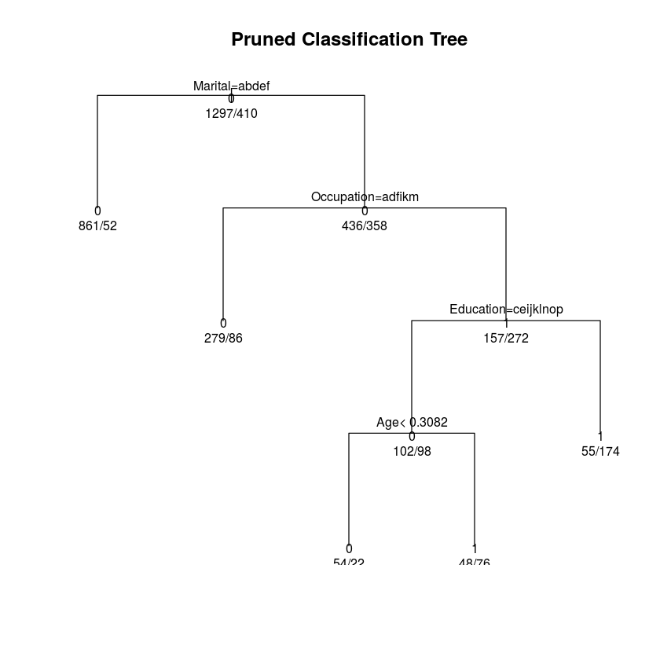

```
		error= 0.1894737
10 -fold CV run 6 dtree_pruned : #training: 1707 #testing 190
```

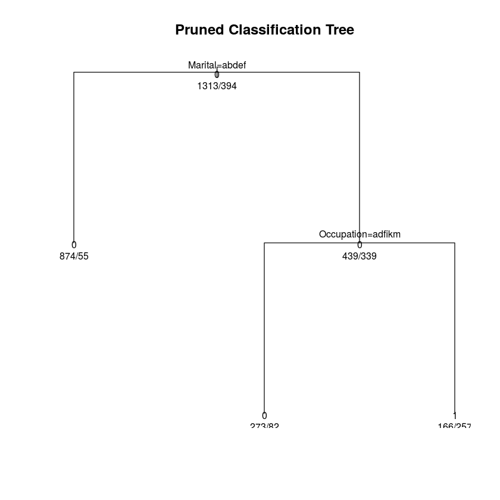

```
		error= 0.2
10 -fold CV run 7 dtree_pruned : #training: 1707 #testing 190
```

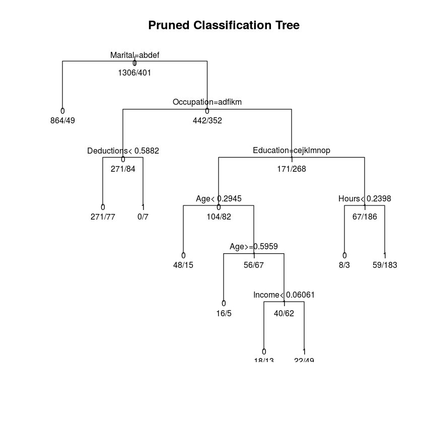

```
		error= 0.1736842
10 -fold CV run 8 dtree_pruned : #training: 1707 #testing 190
```

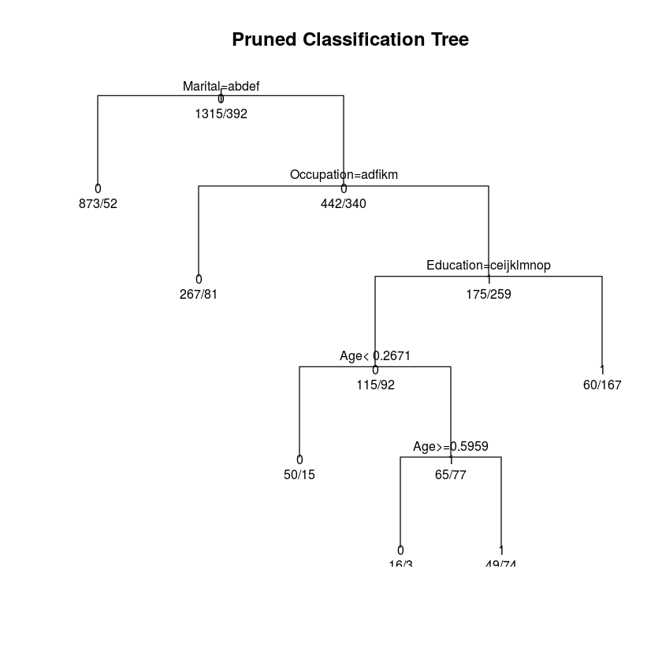

```
		error= 0.2315789
10 -fold CV run 9 dtree_pruned : #training: 1708 #testing 189
```

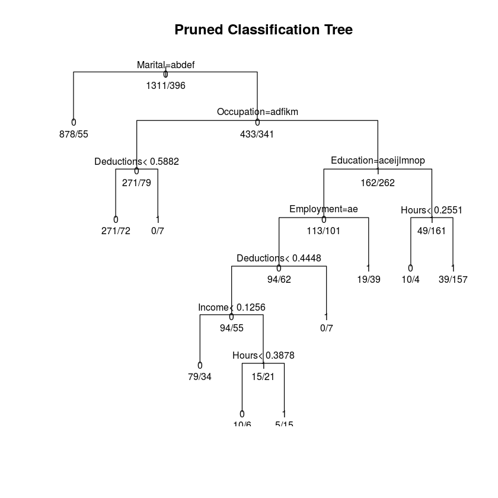

```
		error= 0.1640212
10 -fold CV run 10 dtree_pruned : #training: 1708 #testing 189
```

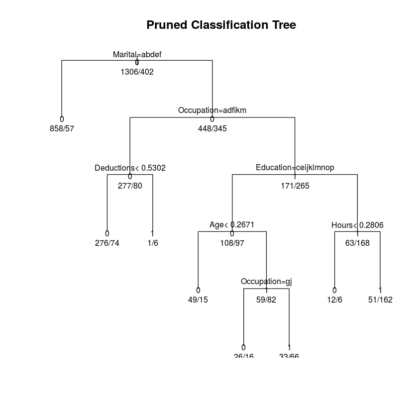

```
		error= 0.1534392
10 -fold CV results: avg error= 0.1760345
error= 0.2644801 precision= 0.5615667 recall= 0.5574315 f-score 0.4861831
auc= 0.8104752
```

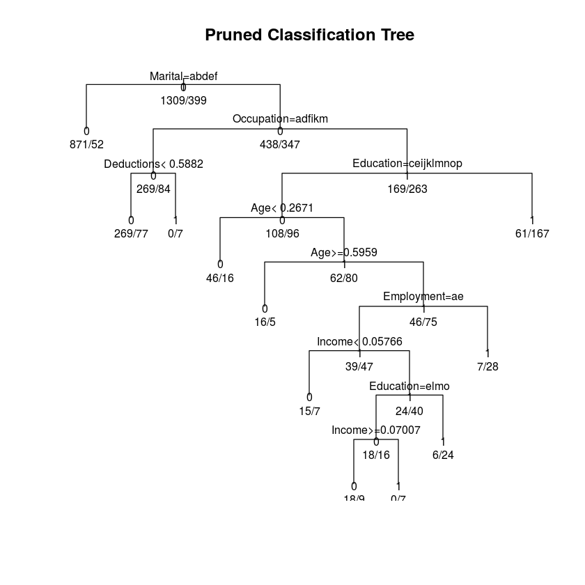

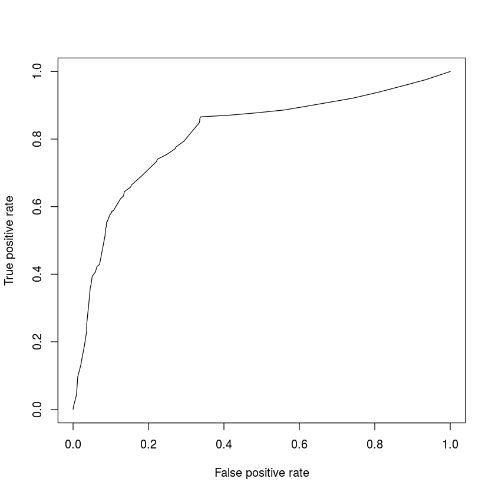

```r
my.classifier(ad, cl.name='dtree_pruned',do.cv=T)
```

```
my dataset: 1897 observations 9 predictors
  y       Age Employment Education   Marital Occupation    Income Gender
1 0 0.2876712    Private   College Unmarried    Service 0.1689968 Female
2 0 0.2465753    Private Associate    Absent  Transport 0.1487347   Male
3 0 0.2054795    Private    HSgrad  Divorced   Clerical 0.3205390   Male
  Deductions     Hours
1          0 0.7244898
2          0 0.2959184
3          0 0.3979592
label (y) distribution:
   0    1
1450  447
10 -fold CV run 1 svm_radial_not_tuned : #training: 1708 #testing 189
		error= 0.1428571
10 -fold CV run 2 svm_radial_not_tuned : #training: 1707 #testing 190
		error= 0.1684211
10 -fold CV run 3 svm_radial_not_tuned : #training: 1707 #testing 190
		error= 0.1315789
10 -fold CV run 4 svm_radial_not_tuned : #training: 1707 #testing 190
		error= 0.2
10 -fold CV run 5 svm_radial_not_tuned : #training: 1707 #testing 190
		error= 0.1894737
10 -fold CV run 6 svm_radial_not_tuned : #training: 1707 #testing 190
		error= 0.1631579
10 -fold CV run 7 svm_radial_not_tuned : #training: 1707 #testing 190
		error= 0.1736842
10 -fold CV run 8 svm_radial_not_tuned : #training: 1707 #testing 190
		error= 0.1947368
10 -fold CV run 9 svm_radial_not_tuned : #training: 1708 #testing 189
		error= 0.1851852
10 -fold CV run 10 svm_radial_not_tuned : #training: 1708 #testing 189
		error= 0.1428571
10 -fold CV results: avg error= 0.1691952
error= 0.3646167 precision= 0.4787017 recall= 0.7876395 f-score 0.5107969
auc= 0.8763164
```

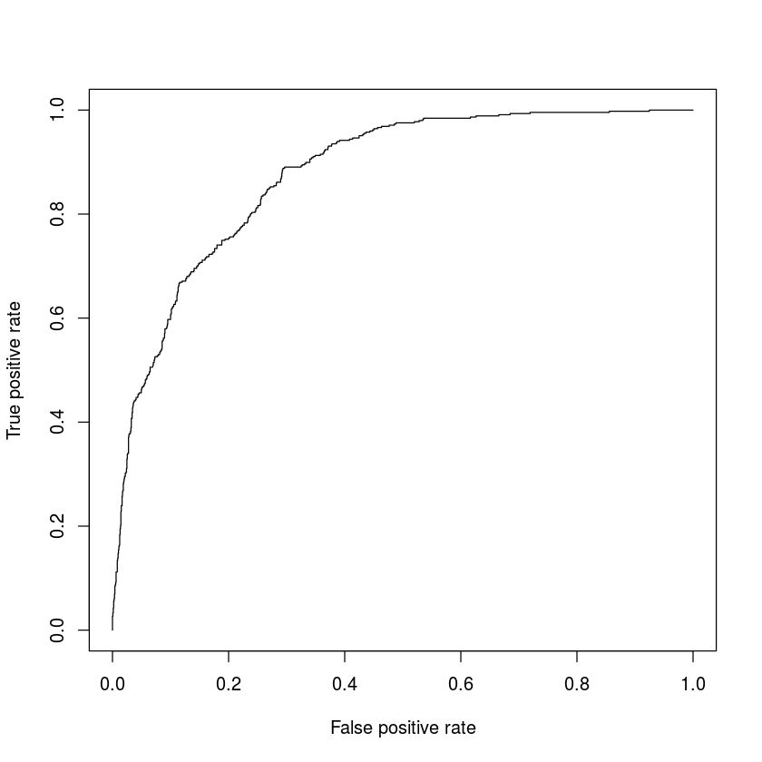

```r
my.classifier(ad, cl.name='svm_radial_not_tuned',do.cv=T)
```

```
my dataset: 1897 observations 9 predictors
  y       Age Employment Education   Marital Occupation    Income Gender
1 0 0.2876712    Private   College Unmarried    Service 0.1689968 Female
2 0 0.2465753    Private Associate    Absent  Transport 0.1487347   Male
3 0 0.2054795    Private    HSgrad  Divorced   Clerical 0.3205390   Male
  Deductions     Hours
1          0 0.7244898
2          0 0.2959184
3          0 0.3979592
label (y) distribution:
   0    1
1450  447
10 -fold CV run 1 svm_radial_tuned : #training: 1708 #testing 189
		error= 0.2010582
10 -fold CV run 2 svm_radial_tuned : #training: 1707 #testing 190
		error= 0.1473684
10 -fold CV run 3 svm_radial_tuned : #training: 1707 #testing 190
		error= 0.1526316
10 -fold CV run 4 svm_radial_tuned : #training: 1707 #testing 190
		error= 0.1368421
10 -fold CV run 5 svm_radial_tuned : #training: 1707 #testing 190
		error= 0.1842105
10 -fold CV run 6 svm_radial_tuned : #training: 1707 #testing 190
		error= 0.1684211
10 -fold CV run 7 svm_radial_tuned : #training: 1707 #testing 190
		error= 0.1315789
10 -fold CV run 8 svm_radial_tuned : #training: 1707 #testing 190
		error= 0.1736842
10 -fold CV run 9 svm_radial_tuned : #training: 1708 #testing 189
		error= 0.1587302
10 -fold CV run 10 svm_radial_tuned : #training: 1708 #testing 189
		error= 0.1428571
10 -fold CV results: avg error= 0.1597382
error= 0.3631814 precision= 0.4838285 recall= 0.7928052 f-score 0.5150518
auc= 0.8821068
```

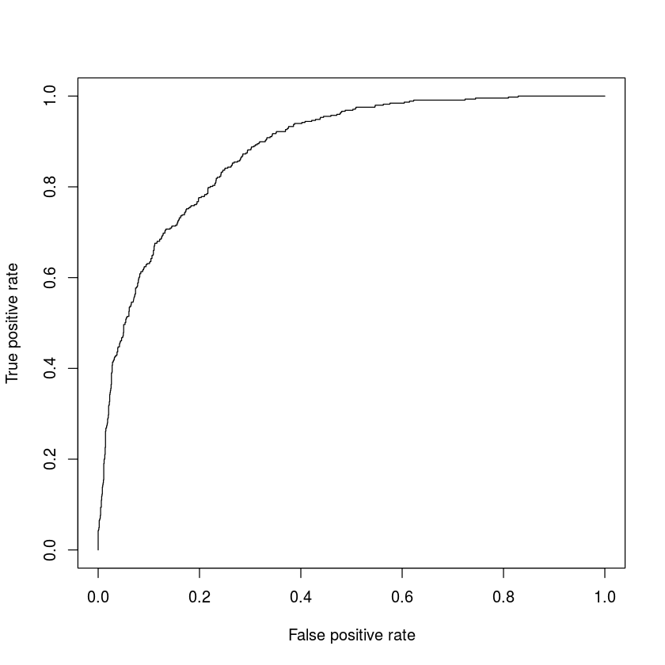

```r
my.classifier(ad, cl.name='svm_radial_tuned',do.cv=T)
```

```
my dataset: 1897 observations 9 predictors
  y       Age Employment Education   Marital Occupation    Income Gender
1 0 0.2876712    Private   College Unmarried    Service 0.1689968 Female
2 0 0.2465753    Private Associate    Absent  Transport 0.1487347   Male
3 0 0.2054795    Private    HSgrad  Divorced   Clerical 0.3205390   Male
  Deductions     Hours
1          0 0.7244898
2          0 0.2959184
3          0 0.3979592
label (y) distribution:
   0    1
1450  447
10 -fold CV run 1 svm_polynomial_not_tuned : #training: 1708 #testing 189
		error= 0.1693122
10 -fold CV run 2 svm_polynomial_not_tuned : #training: 1707 #testing 190
		error= 0.1315789
10 -fold CV run 3 svm_polynomial_not_tuned : #training: 1707 #testing 190
		error= 0.1526316
10 -fold CV run 4 svm_polynomial_not_tuned : #training: 1707 #testing 190
		error= 0.1473684
10 -fold CV run 5 svm_polynomial_not_tuned : #training: 1707 #testing 190
		error= 0.1736842
10 -fold CV run 6 svm_polynomial_not_tuned : #training: 1707 #testing 190
		error= 0.1842105
10 -fold CV run 7 svm_polynomial_not_tuned : #training: 1707 #testing 190
		error= 0.2052632
10 -fold CV run 8 svm_polynomial_not_tuned : #training: 1707 #testing 190
		error= 0.1631579
10 -fold CV run 9 svm_polynomial_not_tuned : #training: 1708 #testing 189
		error= 0.1534392
10 -fold CV run 10 svm_polynomial_not_tuned : #training: 1708 #testing 189
		error= 0.1322751
10 -fold CV results: avg error= 0.1612921
error= 0.3648481 precision= 0.4795467 recall= 0.7893223 f-score 0.5115071
auc= 0.8774674
```

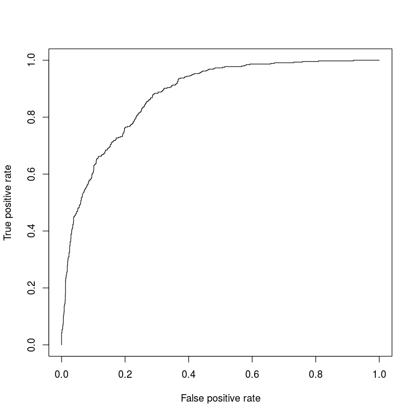

```r
my.classifier(ad, cl.name='svm_polynomial_not_tuned',do.cv=T)
```

```
my dataset: 1897 observations 9 predictors
  y       Age Employment Education   Marital Occupation    Income Gender
1 0 0.2876712    Private   College Unmarried    Service 0.1689968 Female
2 0 0.2465753    Private Associate    Absent  Transport 0.1487347   Male
3 0 0.2054795    Private    HSgrad  Divorced   Clerical 0.3205390   Male
  Deductions     Hours
1          0 0.7244898
2          0 0.2959184
3          0 0.3979592
label (y) distribution:
   0    1
1450  447
10 -fold CV run 1 svm_polynomial_tuned : #training: 1708 #testing 189
		error= 0.1851852
10 -fold CV run 2 svm_polynomial_tuned : #training: 1707 #testing 190
		error= 0.1421053
10 -fold CV run 3 svm_polynomial_tuned : #training: 1707 #testing 190
		error= 0.1526316
10 -fold CV run 4 svm_polynomial_tuned : #training: 1707 #testing 190
		error= 0.1894737
10 -fold CV run 5 svm_polynomial_tuned : #training: 1707 #testing 190
		error= 0.2473684
10 -fold CV run 6 svm_polynomial_tuned : #training: 1707 #testing 190
		error= 0.1631579
10 -fold CV run 7 svm_polynomial_tuned : #training: 1707 #testing 190
		error= 0.1842105
10 -fold CV run 8 svm_polynomial_tuned : #training: 1707 #testing 190
		error= 0.1368421
10 -fold CV run 9 svm_polynomial_tuned : #training: 1708 #testing 189
		error= 0.1269841
10 -fold CV run 10 svm_polynomial_tuned : #training: 1708 #testing 189
		error= 0.1851852
10 -fold CV results: avg error= 0.1713144
error= 0.3713419 precision= 0.4634801 recall= 0.7752695 f-score 0.500212
auc= 0.8591051
```

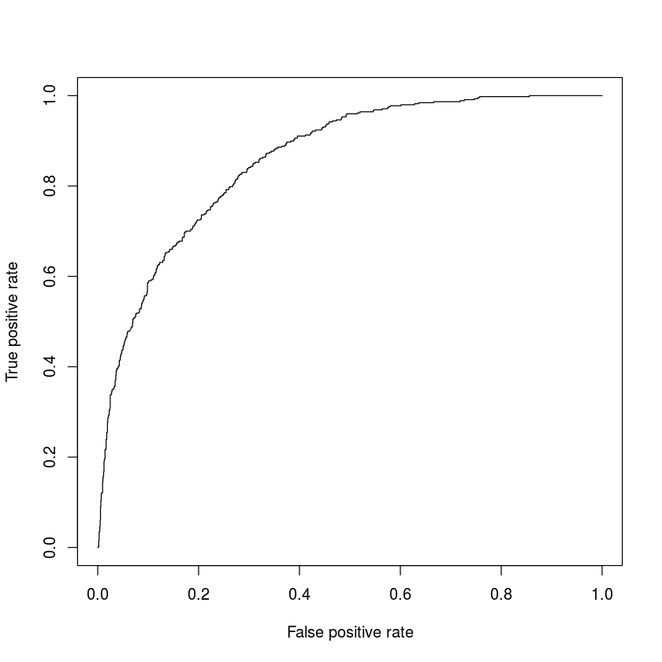

```r
my.classifier(ad, cl.name='svm_polynomial_tuned',do.cv=T)
```

```
my dataset: 1897 observations 9 predictors
  y       Age Employment Education   Marital Occupation    Income Gender
1 0 0.2876712    Private   College Unmarried    Service 0.1689968 Female
2 0 0.2465753    Private Associate    Absent  Transport 0.1487347   Male
3 0 0.2054795    Private    HSgrad  Divorced   Clerical 0.3205390   Male
  Deductions     Hours
1          0 0.7244898
2          0 0.2959184
3          0 0.3979592
label (y) distribution:
   0    1
1450  447
10 -fold CV run 1 svm_linear_not_tuned : #training: 1708 #testing 189
		error= 0.1322751
10 -fold CV run 2 svm_linear_not_tuned : #training: 1707 #testing 190
		error= 0.1421053
10 -fold CV run 3 svm_linear_not_tuned : #training: 1707 #testing 190
		error= 0.2
10 -fold CV run 4 svm_linear_not_tuned : #training: 1707 #testing 190
		error= 0.1578947
10 -fold CV run 5 svm_linear_not_tuned : #training: 1707 #testing 190
		error= 0.1684211
10 -fold CV run 6 svm_linear_not_tuned : #training: 1707 #testing 190
		error= 0.1842105
10 -fold CV run 7 svm_linear_not_tuned : #training: 1707 #testing 190
		error= 0.1578947
10 -fold CV run 8 svm_linear_not_tuned : #training: 1707 #testing 190
		error= 0.1421053
10 -fold CV run 9 svm_linear_not_tuned : #training: 1708 #testing 189
		error= 0.1534392
10 -fold CV run 10 svm_linear_not_tuned : #training: 1708 #testing 189
		error= 0.2222222
10 -fold CV results: avg error= 0.1660568
error= 0.3662891 precision= 0.4774503 recall= 0.7884417 f-score 0.5096994
auc= 0.8751948
```

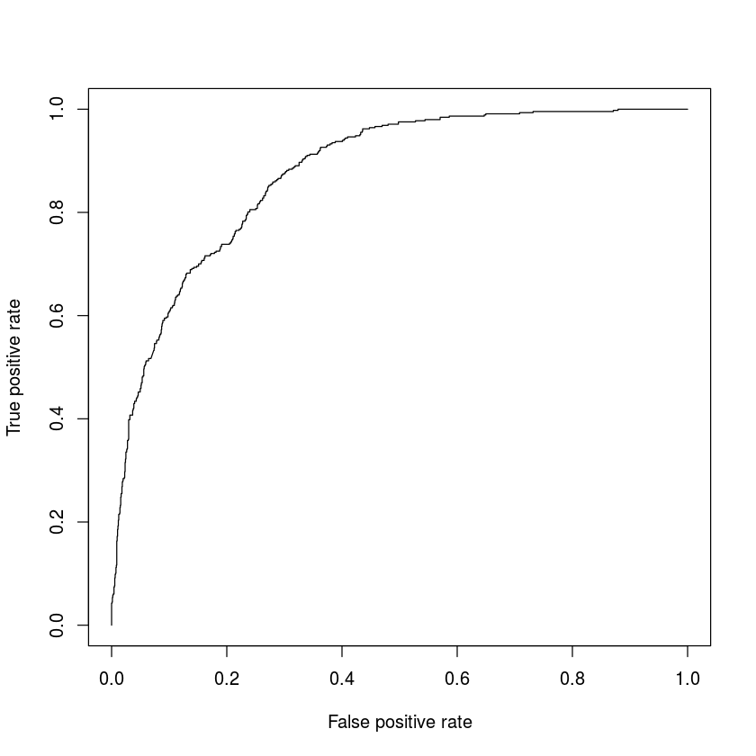

```r
my.classifier(ad, cl.name='svm_linear_not_tuned',do.cv=T)
```

```
my dataset: 1897 observations 9 predictors
  y       Age Employment Education   Marital Occupation    Income Gender
1 0 0.2876712    Private   College Unmarried    Service 0.1689968 Female
2 0 0.2465753    Private Associate    Absent  Transport 0.1487347   Male
3 0 0.2054795    Private    HSgrad  Divorced   Clerical 0.3205390   Male
  Deductions     Hours
1          0 0.7244898
2          0 0.2959184
3          0 0.3979592
label (y) distribution:
   0    1
1450  447
10 -fold CV run 1 svm_linear_tuned : #training: 1708 #testing 189
		error= 0.1904762
10 -fold CV run 2 svm_linear_tuned : #training: 1707 #testing 190
		error= 0.2684211
10 -fold CV run 3 svm_linear_tuned : #training: 1707 #testing 190
		error= 0.2894737
10 -fold CV run 4 svm_linear_tuned : #training: 1707 #testing 190
		error= 0.2263158
10 -fold CV run 5 svm_linear_tuned : #training: 1707 #testing 190
		error= 0.2210526
10 -fold CV run 6 svm_linear_tuned : #training: 1707 #testing 190
		error= 0.2473684
10 -fold CV run 7 svm_linear_tuned : #training: 1707 #testing 190
		error= 0.1631579
10 -fold CV run 8 svm_linear_tuned : #training: 1707 #testing 190
		error= 0.1736842
10 -fold CV run 9 svm_linear_tuned : #training: 1708 #testing 189
		error= 0.2328042
10 -fold CV run 10 svm_linear_tuned : #training: 1708 #testing 189
		error= 0.1640212
10 -fold CV results: avg error= 0.2176775
error= 0.3789097 precision= 0.4347081 recall= 0.761838 f-score 0.4807186
auc= 0.8389516
```

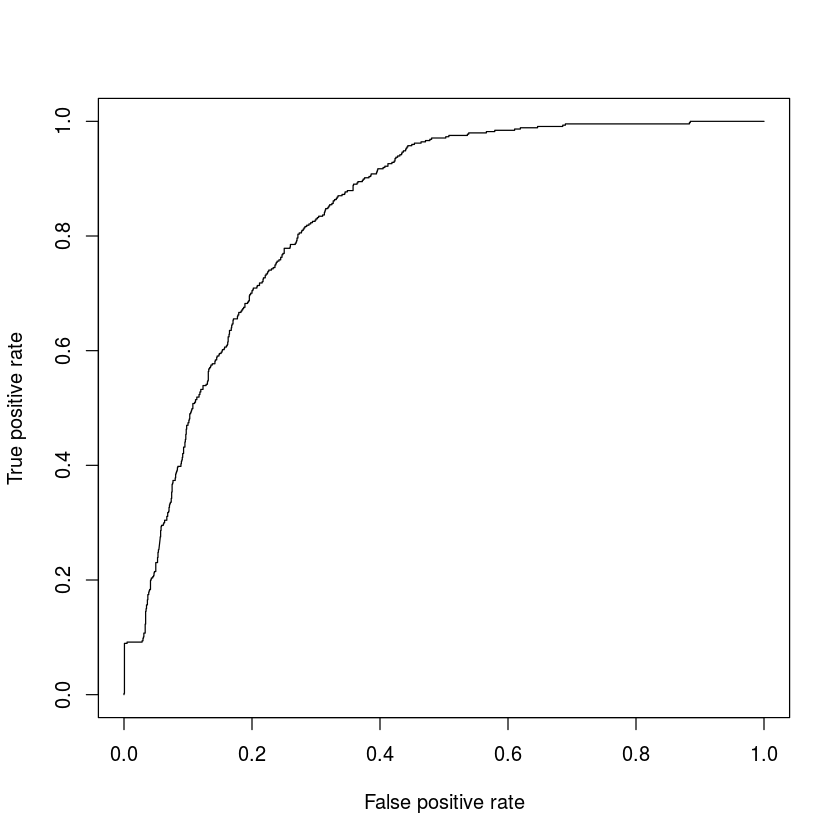

```r
my.classifier(ad, cl.name='svm_linear_tuned',do.cv=T)
```

```
my dataset: 1897 observations 9 predictors
  y       Age Employment Education   Marital Occupation    Income Gender
1 0 0.2876712    Private   College Unmarried    Service 0.1689968 Female
2 0 0.2465753    Private Associate    Absent  Transport 0.1487347   Male
3 0 0.2054795    Private    HSgrad  Divorced   Clerical 0.3205390   Male
  Deductions     Hours
1          0 0.7244898
2          0 0.2959184
3          0 0.3979592
label (y) distribution:
   0    1
1450  447
10 -fold CV run 1 ada : #training: 1708 #testing 189
		error= 0.1746032
10 -fold CV run 2 ada : #training: 1707 #testing 190
		error= 0.1473684
10 -fold CV run 3 ada : #training: 1707 #testing 190
		error= 0.1789474
10 -fold CV run 4 ada : #training: 1707 #testing 190
		error= 0.1789474
10 -fold CV run 5 ada : #training: 1707 #testing 190
		error= 0.1736842
10 -fold CV run 6 ada : #training: 1707 #testing 190
		error= 0.1263158
10 -fold CV run 7 ada : #training: 1707 #testing 190
		error= 0.1631579
10 -fold CV run 8 ada : #training: 1707 #testing 190
		error= 0.1315789
10 -fold CV run 9 ada : #training: 1708 #testing 189
		error= 0.1375661
10 -fold CV run 10 ada : #training: 1708 #testing 189
		error= 0.1587302
10 -fold CV results: avg error= 0.1570899
error= 0.3028692 precision= 0.526608 recall= 0.7483968 f-score 0.5332154
auc= 0.8787595
```

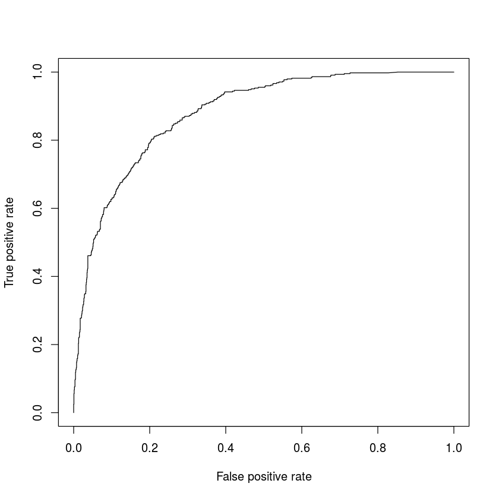

```r
my.classifier(ad, cl.name='ada',do.cv=T)
```

| y | Age | NAEmploymentConsultant | NAEmploymentPSFederal | NAEmploymentPSLocal | NAEmploymentPSState | NAEmploymentPrivate | NAEmploymentSelfEmp | NAEducationAssociate | NAEducationBachelor | ... | NAOccupationRepair | NAOccupationSales | NAOccupationService | NAOccupationSupport | NAOccupationTransport | Income | NAGenderFemale | NAGenderMale | Deductions | Hours |
| --- | --- | --- | --- | --- | --- | --- | --- | --- | --- | --- | --- | --- | --- | --- | --- | --- | --- | --- | --- | --- |
| 0 | 0.2876712 | 0 | 0 | 0 | 0 | 1 | 0 | 0 | 0 | ... | 0 | 0 | 1 | 0 | 0 | 0.16899681 | 1 | 0 | 0 | 0.7244898 |
| 0 | 0.2465753 | 0 | 0 | 0 | 0 | 1 | 0 | 1 | 0 | ... | 0 | 0 | 0 | 0 | 1 | 0.14873466 | 0 | 1 | 0 | 0.2959184 |
| 0 | 0.2054795 | 0 | 0 | 0 | 0 | 1 | 0 | 0 | 0 | ... | 0 | 0 | 0 | 0 | 0 | 0.32053904 | 0 | 1 | 0 | 0.3979592 |
| 1 | 0.3835616 | 0 | 0 | 0 | 0 | 1 | 0 | 0 | 1 | ... | 1 | 0 | 0 | 0 | 0 | 0.05645295 | 0 | 1 | 0 | 0.5510204 |
| 1 | 0.5890411 | 0 | 0 | 0 | 0 | 1 | 0 | 0 | 0 | ... | 0 | 0 | 0 | 0 | 0 | 0.01447730 | 0 | 1 | 0 | 0.3979592 |
| 0 | 0.7808219 | 0 | 0 | 0 | 0 | 1 | 0 | 0 | 0 | ... | 0 | 0 | 1 | 0 | 0 | 0.06768895 | 0 | 1 | 0 | 0.2959184 |

```
my dataset: 1897 observations 9 predictors
  y       Age NAEmploymentConsultant NAEmploymentPSFederal NAEmploymentPSLocal
1 0 0.2876712                      0                     0                   0
2 0 0.2465753                      0                     0                   0
3 0 0.2054795                      0                     0                   0
  NAEmploymentPSState NAEmploymentPrivate NAEmploymentSelfEmp
1                   0                   1                   0
2                   0                   1                   0
3                   0                   1                   0
  NAEducationAssociate NAEducationBachelor NAEducationCollege
1                    0                   0                  1
2                    1                   0                  0
3                    0                   0                  0
  NAEducationDoctorate NAEducationHSgrad NAEducationMaster NAEducationPreschool
1                    0                 0                 0                    0
2                    0                 0                 0                    0
3                    0                 1                 0                    0
  NAEducationProfessional NAEducationVocational NAEducationYr10 NAEducationYr11
1                       0                     0               0               0
2                       0                     0               0               0
3                       0                     0               0               0
  NAEducationYr12 NAEducationYr1t4 NAEducationYr5t6 NAEducationYr7t8
1               0                0                0                0
2               0                0                0                0
3               0                0                0                0
  NAEducationYr9 NAMaritalAbsent NAMaritalDivorced NAMaritalMarried
1              0               0                 0                0
2              0               1                 0                0
3              0               0                 1                0
  NAMaritalMarried-spouse-absent NAMaritalUnmarried NAMaritalWidowed
1                              0                  1                0
2                              0                  0                0
3                              0                  0                0
  NAOccupationCleaner NAOccupationClerical NAOccupationExecutive
1                   0                    0                     0
2                   0                    0                     0
3                   0                    1                     0
  NAOccupationFarming NAOccupationHome NAOccupationMachinist
1                   0                0                     0
2                   0                0                     0
```

[output cut: 28 more lines]

```
10 -fold CV run 5 knn1 : #training: 1707 #testing 190
		error= 0.7368421
10 -fold CV run 6 knn1 : #training: 1707 #testing 190
		error= 0.7473684
10 -fold CV run 7 knn1 : #training: 1707 #testing 190
		error= 0.8157895
10 -fold CV run 8 knn1 : #training: 1707 #testing 190
		error= 0.8052632
10 -fold CV run 9 knn1 : #training: 1708 #testing 189
		error= 0.7936508
10 -fold CV run 10 knn1 : #training: 1708 #testing 189
		error= 0.7513228
10 -fold CV results: avg error= 0.7643693
error= 0.5 precision= 0.2356352 recall= 0.5 f-score 0.3813993
auc= 0.5
```

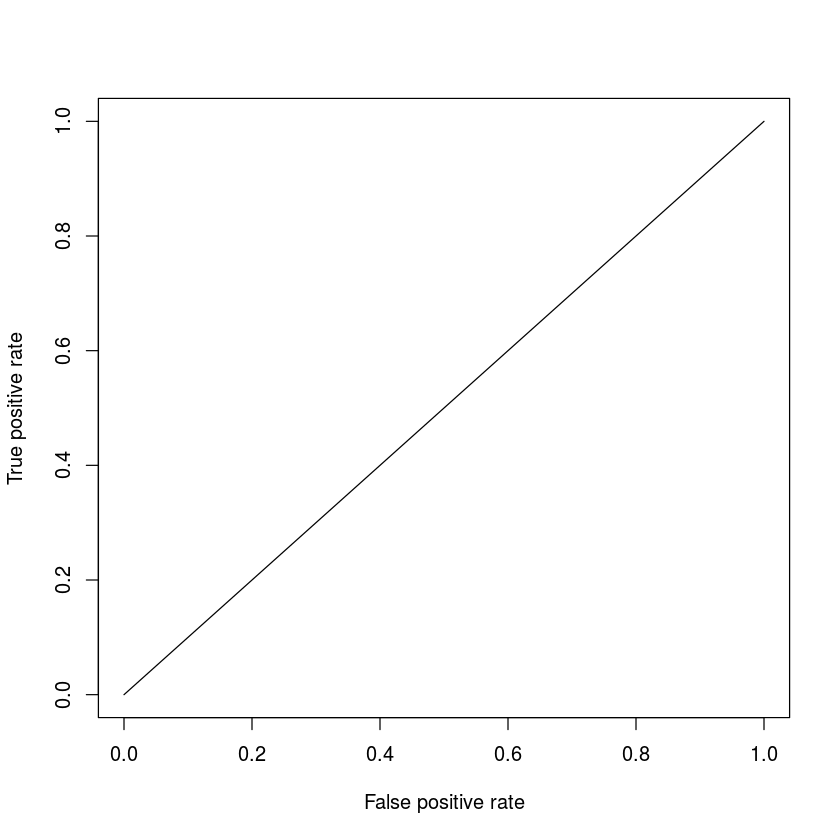

```r
ad_knn = cbind(ad['y'],ad['Age'],dummy(ad$Employment, sep='Employment'),dummy(ad$Education, sep='Education'),
               dummy(ad$Marital, sep='Marital'),dummy(ad$Occupation, sep='Occupation'),ad['Income'],dummy(ad$Gender, sep='Gender'),ad['Deductions'],ad['Hours'])
ad_knn$y <- as.factor(ad_knn$y)
head(ad_knn)
my.classifier(ad_knn, cl.name='knn1',do.cv=T)
```

```
my dataset: 1897 observations 9 predictors
  y       Age NAEmploymentConsultant NAEmploymentPSFederal NAEmploymentPSLocal
1 0 0.2876712                      0                     0                   0
2 0 0.2465753                      0                     0                   0
3 0 0.2054795                      0                     0                   0
  NAEmploymentPSState NAEmploymentPrivate NAEmploymentSelfEmp
1                   0                   1                   0
2                   0                   1                   0
3                   0                   1                   0
  NAEducationAssociate NAEducationBachelor NAEducationCollege
1                    0                   0                  1
2                    1                   0                  0
3                    0                   0                  0
  NAEducationDoctorate NAEducationHSgrad NAEducationMaster NAEducationPreschool
1                    0                 0                 0                    0
2                    0                 0                 0                    0
3                    0                 1                 0                    0
  NAEducationProfessional NAEducationVocational NAEducationYr10 NAEducationYr11
1                       0                     0               0               0
2                       0                     0               0               0
3                       0                     0               0               0
  NAEducationYr12 NAEducationYr1t4 NAEducationYr5t6 NAEducationYr7t8
1               0                0                0                0
2               0                0                0                0
3               0                0                0                0
  NAEducationYr9 NAMaritalAbsent NAMaritalDivorced NAMaritalMarried
1              0               0                 0                0
2              0               1                 0                0
3              0               0                 1                0
  NAMaritalMarried-spouse-absent NAMaritalUnmarried NAMaritalWidowed
1                              0                  1                0
2                              0                  0                0
3                              0                  0                0
  NAOccupationCleaner NAOccupationClerical NAOccupationExecutive
1                   0                    0                     0
2                   0                    0                     0
3                   0                    1                     0
  NAOccupationFarming NAOccupationHome NAOccupationMachinist
1                   0                0                     0
2                   0                0                     0
```

[output cut: 28 more lines]

```
10 -fold CV run 5 knn3 : #training: 1707 #testing 190
		error= 0.7684211
10 -fold CV run 6 knn3 : #training: 1707 #testing 190
		error= 0.7894737
10 -fold CV run 7 knn3 : #training: 1707 #testing 190
		error= 0.7
10 -fold CV run 8 knn3 : #training: 1707 #testing 190
		error= 0.7578947
10 -fold CV run 9 knn3 : #training: 1708 #testing 189
		error= 0.7883598
10 -fold CV run 10 knn3 : #training: 1708 #testing 189
		error= 0.8359788
10 -fold CV results: avg error= 0.7633389
error= 0.6439491 precision= 0.2019727 recall= 0.6232023 f-score 0.3136319
auc= 0.3789316
```

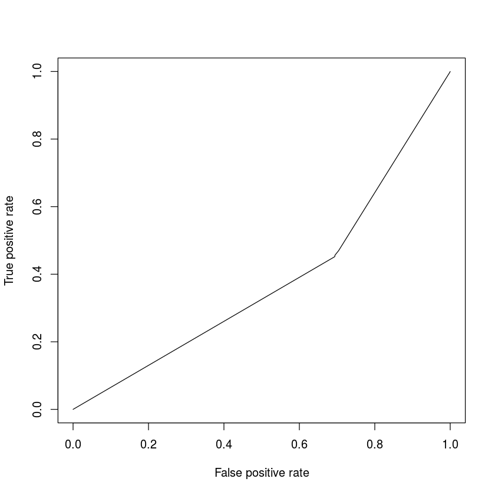

```r
my.classifier(ad_knn, cl.name='knn3',do.cv=T)
```

```
my dataset: 1897 observations 9 predictors
  y       Age NAEmploymentConsultant NAEmploymentPSFederal NAEmploymentPSLocal
1 0 0.2876712                      0                     0                   0
2 0 0.2465753                      0                     0                   0
3 0 0.2054795                      0                     0                   0
  NAEmploymentPSState NAEmploymentPrivate NAEmploymentSelfEmp
1                   0                   1                   0
2                   0                   1                   0
3                   0                   1                   0
  NAEducationAssociate NAEducationBachelor NAEducationCollege
1                    0                   0                  1
2                    1                   0                  0
3                    0                   0                  0
  NAEducationDoctorate NAEducationHSgrad NAEducationMaster NAEducationPreschool
1                    0                 0                 0                    0
2                    0                 0                 0                    0
3                    0                 1                 0                    0
  NAEducationProfessional NAEducationVocational NAEducationYr10 NAEducationYr11
1                       0                     0               0               0
2                       0                     0               0               0
3                       0                     0               0               0
  NAEducationYr12 NAEducationYr1t4 NAEducationYr5t6 NAEducationYr7t8
1               0                0                0                0
2               0                0                0                0
3               0                0                0                0
  NAEducationYr9 NAMaritalAbsent NAMaritalDivorced NAMaritalMarried
1              0               0                 0                0
2              0               1                 0                0
3              0               0                 1                0
  NAMaritalMarried-spouse-absent NAMaritalUnmarried NAMaritalWidowed
1                              0                  1                0
2                              0                  0                0
3                              0                  0                0
  NAOccupationCleaner NAOccupationClerical NAOccupationExecutive
1                   0                    0                     0
2                   0                    0                     0
3                   0                    1                     0
  NAOccupationFarming NAOccupationHome NAOccupationMachinist
1                   0                0                     0
2                   0                0                     0
```

[output cut: 28 more lines]

```
10 -fold CV run 5 knn5 : #training: 1707 #testing 190
		error= 0.7736842
10 -fold CV run 6 knn5 : #training: 1707 #testing 190
		error= 0.7578947
10 -fold CV run 7 knn5 : #training: 1707 #testing 190
		error= 0.7736842
10 -fold CV run 8 knn5 : #training: 1707 #testing 190
		error= 0.7263158
10 -fold CV run 9 knn5 : #training: 1708 #testing 189
		error= 0.7883598
10 -fold CV run 10 knn5 : #training: 1708 #testing 189
		error= 0.7619048
10 -fold CV results: avg error= 0.7617349
error= 0.6599084 precision= 0.1790819 recall= 0.5517123 f-score 0.2727003
auc= 0.3278277
```

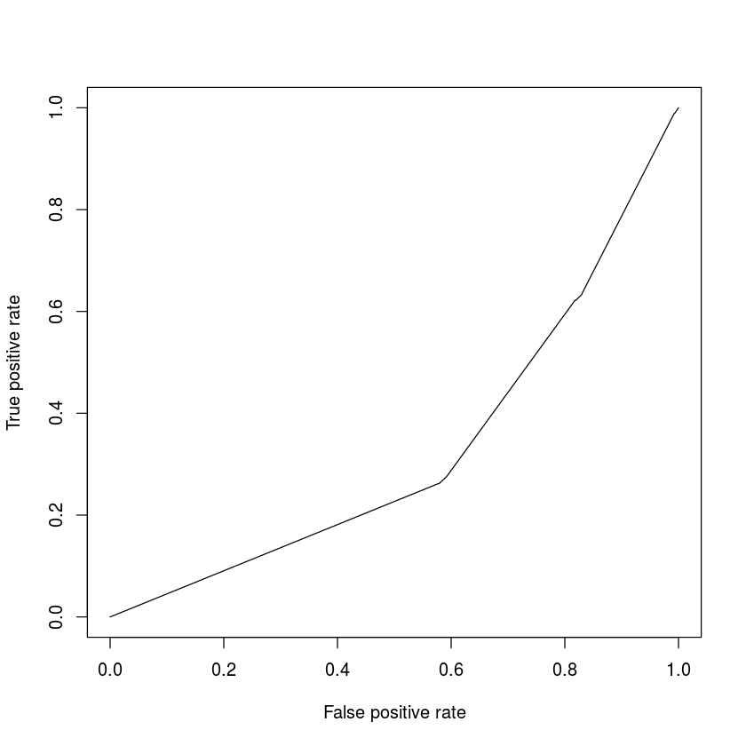

```r
my.classifier(ad_knn, cl.name='knn5',do.cv=T)
```

```r
performances
```

| performances | Model | Accuracy | Precision | Recall | F-score | AUC |
| --- | --- | --- | --- | --- | --- | --- |
|  | lr | 0.633974502472708 | 0.476072949974534 | 0.78428370379276 | 0.509026563822711 | 0.872117565378391 |
|  | nb | 0.621922921112537 | 0.439635991055134 | 0.776583679214293 | 0.495538989938546 | 0.845701612281118 |
|  | dtree_not_pruned | 0.746663707238576 | 0.600209250584395 | 0.566142705757683 | 0.503474460090597 | 0.82035254184988 |
|  | dtree_pruned | 0.735519899841856 | 0.561566656333608 | 0.557431487695749 | 0.486183132290862 | 0.81047519864229 |
|  | svm_radial_not_tuned | 0.635383282818445 | 0.478701737362543 | 0.78763949672095 | 0.510796868358437 | 0.876316439095899 |
|  | svm_radial_tuned | 0.636818634560902 | 0.483828467287762 | 0.792805198769161 | 0.515051839151446 | 0.882106765409244 |
|  | svm_polynomial_not_tuned | 0.635151887516458 | 0.479546703003453 | 0.789322316826318 | 0.511507053183129 | 0.877467407235989 |
|  | svm_polynomial_tuned | 0.628658134965524 | 0.463480131425608 | 0.77526947325605 | 0.500211958035779 | 0.859105145413875 |
|  | svm_linear_not_tuned | 0.633710913084879 | 0.477450282270559 | 0.788441659397457 | 0.509699360227554 | 0.875194785157764 |
|  | svm_linear_tuned | 0.621090283126315 | 0.43470808104621 | 0.761838032268352 | 0.480718628084447 | 0.838951631566779 |
|  | ada | 0.697130827011761 | 0.526608044787891 | 0.748396812784925 | 0.533215445178105 | 0.878759546401298 |
|  | knn1 | 0.5 | 0.235635213494992 | 0.5 | 0.381399317406143 | 0.5 |
|  | knn3 | 0.35605090744785 | 0.201972707095621 | 0.62320230105465 | 0.313631865195085 | 0.378931574481216 |
|  | knn5 | 0.340091642674669 | 0.179081896194969 | 0.551712269833075 | 0.272700253690663 | 0.327827663349533 |

### Generate Two Barcharts

```r
short.names <- c("short name","lr","nb","dnp","dp","sr","srt","sp","spt","sl","slt","ada","k1","k3","k5")
performances.plus <- cbind(short.names,performances)
performances.plus
```

|  | short.names |  |  |  |  |  |  |
| --- | --- | --- | --- | --- | --- | --- | --- |
| performances | short name | Model | Accuracy | Precision | Recall | F-score | AUC |
|  | lr | lr | 0.633974502472708 | 0.476072949974534 | 0.78428370379276 | 0.509026563822711 | 0.872117565378391 |
|  | nb | nb | 0.621922921112537 | 0.439635991055134 | 0.776583679214293 | 0.495538989938546 | 0.845701612281118 |
|  | dnp | dtree_not_pruned | 0.746663707238576 | 0.600209250584395 | 0.566142705757683 | 0.503474460090597 | 0.82035254184988 |
|  | dp | dtree_pruned | 0.735519899841856 | 0.561566656333608 | 0.557431487695749 | 0.486183132290862 | 0.81047519864229 |
|  | sr | svm_radial_not_tuned | 0.635383282818445 | 0.478701737362543 | 0.78763949672095 | 0.510796868358437 | 0.876316439095899 |
|  | srt | svm_radial_tuned | 0.636818634560902 | 0.483828467287762 | 0.792805198769161 | 0.515051839151446 | 0.882106765409244 |
|  | sp | svm_polynomial_not_tuned | 0.635151887516458 | 0.479546703003453 | 0.789322316826318 | 0.511507053183129 | 0.877467407235989 |
|  | spt | svm_polynomial_tuned | 0.628658134965524 | 0.463480131425608 | 0.77526947325605 | 0.500211958035779 | 0.859105145413875 |
|  | sl | svm_linear_not_tuned | 0.633710913084879 | 0.477450282270559 | 0.788441659397457 | 0.509699360227554 | 0.875194785157764 |
|  | slt | svm_linear_tuned | 0.621090283126315 | 0.43470808104621 | 0.761838032268352 | 0.480718628084447 | 0.838951631566779 |
|  | ada | ada | 0.697130827011761 | 0.526608044787891 | 0.748396812784925 | 0.533215445178105 | 0.878759546401298 |
|  | k1 | knn1 | 0.5 | 0.235635213494992 | 0.5 | 0.381399317406143 | 0.5 |
|  | k3 | knn3 | 0.35605090744785 | 0.201972707095621 | 0.62320230105465 | 0.313631865195085 | 0.378931574481216 |
|  | k5 | knn5 | 0.340091642674669 | 0.179081896194969 | 0.551712269833075 | 0.272700253690663 | 0.327827663349533 |

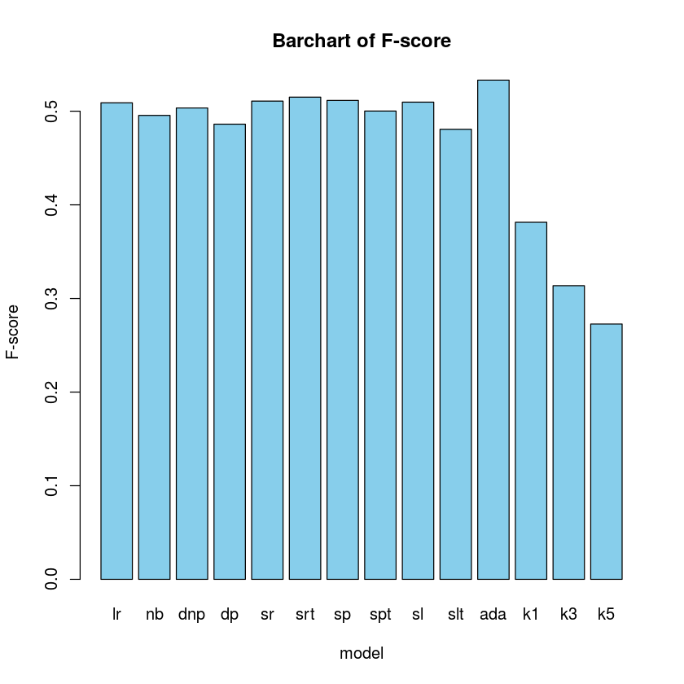

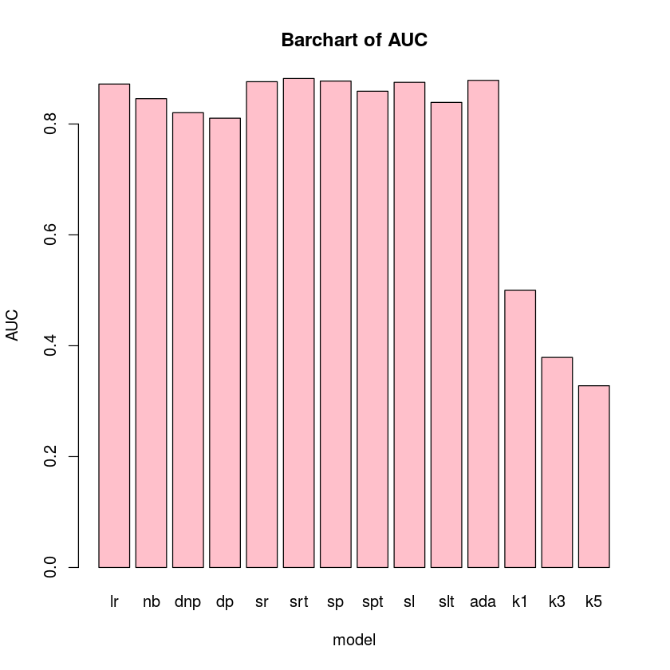

```r
performances.fscore <- rbind(performances.plus[-1,6])
performances.AUC <- rbind(performances.plus[-1,7])
performances.model <- rbind(performances.plus[-1,1])
barplot(performances.fscore,main = "Barchart of F-score",names.arg = performances.model,xlab = "model",ylab = "F-score", col="skyblue")
barplot(performances.AUC,main = "Barchart of AUC",names.arg = performances.model,xlab = "model",ylab = "AUC", col="pink")
```

## ROC Curve

##### Plot all ROC curves

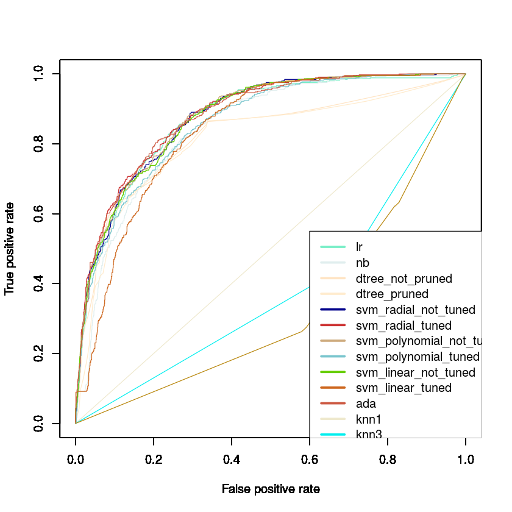

```r
colors_for_legend = c("")
for (i in seq(2,length(roc_data))) {
  color = colors()[i*5]
  plot(roc_data[[i]], col=color)
  par(new=TRUE)
  #print(i*3)
  colors_for_legend = c(colors_for_legend, i*5)
}
colors_for_legend <- colors_for_legend[-1]
#print(colors_for_legend)
colors_for_legend <- colors()[as.numeric(colors_for_legend)]
model_name_for_legend = performances[c(2:length(performances[,1])),1]
#colors_for_legend = seq(3, length(roc_data)*3, by= 3)
legend(0.6,0.55, model_name_for_legend, col=colors_for_legend, lwd=3)
#print(seq(3, length(roc_data)*3, by=3))
```

##### Plot ROC curves selected from each type of model

```r
roc_data_select = cbind(roc_data[2],roc_data[3],roc_data[4],roc_data[7],roc_data[12],roc_data[13])
length(roc_data_select)
```

6

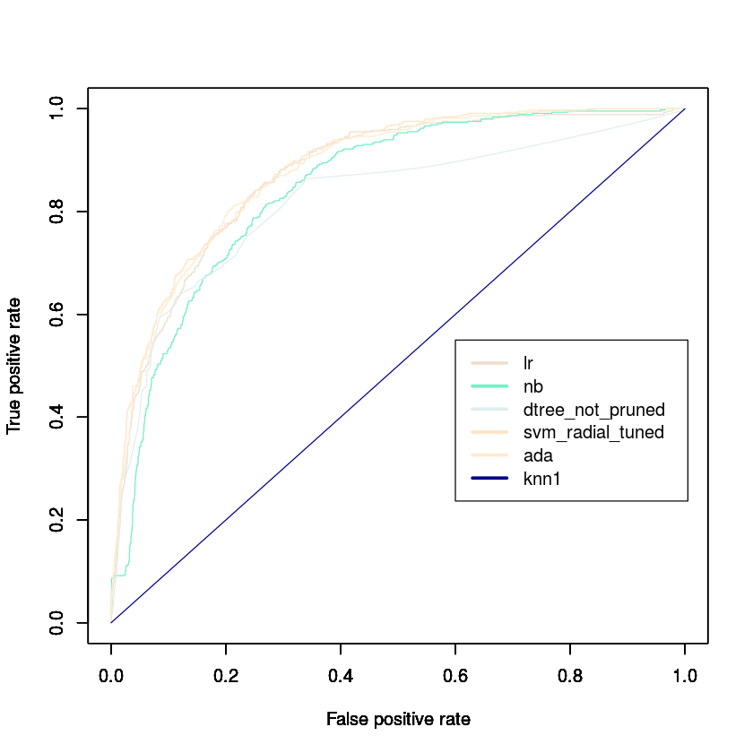

```r
colors_for_legend = c("")
for (i in seq(1,length(roc_data_select))) {
  color = colors()[i*5]
  plot(roc_data_select[[i]], col=color)
  par(new=TRUE)
  #print(i*3)
  colors_for_legend = c(colors_for_legend, i*5)
}
colors_for_legend <- colors_for_legend[-1]
#print(colors_for_legend)
colors_for_legend <- colors()[as.numeric(colors_for_legend)]
model_name_for_legend = performances[c(2:length(performances[,1])),1]
model_name_for_legend_new <- c(model_name_for_legend[1],model_name_for_legend[2],model_name_for_legend[3],model_name_for_legend[6],model_name_for_legend[11],model_name_for_legend[12])
#colors_for_legend = seq(3, length(roc_data)*3, by= 3)
legend(0.6,0.55, model_name_for_legend_new, col=colors_for_legend, lwd=3)
#print(seq(3, length(roc_data)*3, by=3))
```

## Summary

ROC curve plots the true positive rate against false positive rate, and AUC is the area under the ROC curve. The bigger AUC value means the better performance of the model.

Parameter Variation for each method:  
(1) Logistic Regression (lr): no parameter variation  
(2) Naive Bayesian (nb): no parameter variation  
(3) Decision Tree (dt): pruned/not_pruned  
(4) Support Vetecor Machine (svm): [1]linear/polynomial/radial [2]tuned/not_tuned  
(5) Adaptive Boosting (ada): no parameter variation  
(6) K-Nearest-Neighbor (knn): k <- 1/3/5